# SignatureSearch Cortes

```r
result(tsea_kegg_cmap_human)
```

```
## # A tibble: 191 x 9
##    ID     Description  GeneRatio BgRatio   pvalue p.adjust  qvalue itemID  Count
##    <chr>  <chr>        <chr>     <chr>      <dbl>    <dbl>   <dbl> <chr>   <int>
##  1 hsa00… Nitrogen me… 6/53      17/8105 6.84e-10  1.41e-7 6.12e-8 759/23…     6
##  2 hsa04… Adrenergic … 10/53     150/81… 3.44e- 8  3.55e-6 1.54e-6 207/56…    10
##  3 hsa04… Growth horm… 9/53      119/81… 6.03e- 8  4.14e-6 1.80e-6 207/29…     9
##  4 hsa05… Lipid and a… 11/53     215/81… 1.02e- 7  4.17e-6 1.81e-6 207/29…    11
##  5 hsa00… Steroid hor… 7/53      61/8105 1.13e- 7  4.17e-6 1.81e-6 1571/1…     7
##  6 hsa04… Relaxin sig… 9/53      129/81… 1.22e- 7  4.17e-6 1.81e-6 207/56…     9
##  7 hsa05… Yersinia in… 9/53      137/81… 2.04e- 7  5.29e-6 2.30e-6 207/29…     9
##  8 hsa04… AGE-RAGE si… 8/53      100/81… 2.27e- 7  5.29e-6 2.30e-6 207/56…     8
##  9 hsa04… Fc epsilon … 7/53      68/8105 2.42e- 7  5.29e-6 2.30e-6 207/24…     7
## 10 hsa04… MAPK signal… 12/53     294/81… 2.92e- 7  5.29e-6 2.30e-6 207/56…    12
## # … with 181 more rows
```

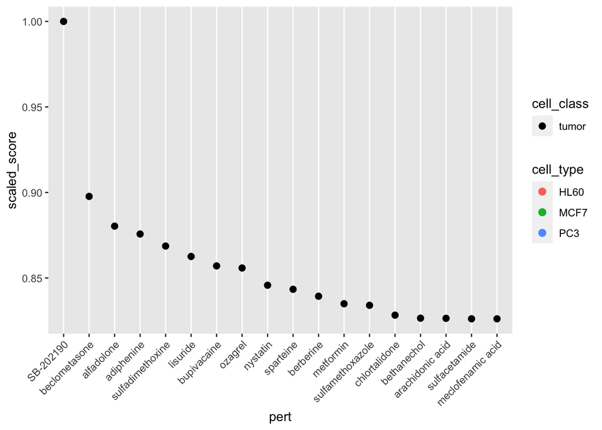

```r
cmap_res_down <- cmap_res[cmap_res$trend =="down",]
cmap_res_up <- cmap_res[cmap_res$trend =="up",]

down_drug_cmap <- unique(cmap_res_down$pert)[1:20]
up_drug_cmap <- unique(cmap_res_up$pert)[1:20]

gess_res_vis(cmap_res, drugs = up_drug_cmap, col = "scaled_score")
```

```r
dtnetplot(drugs = drugs(tsea_kegg_cmap_human), set = "hsa00140",
          desc="Steroid hormone biosynthesis")
```

```
## No targets found in DrugBank/CLUE/STITCH database for 10 drugs:
## tropine / etanidazole / dirithromycin / scopolamine n-oxide / n-acetyl-l-leucine / adrenosterone / cytochalasin b / pentetrazol / alfadolone / adiphenine
```

[interactive chart not shown]

```r
#Metyrapone, sold under the brand name Metopirone, is a medication which is used in the diagnosis of adrenal insufficiency and occasionally in the treatment of Cushing's syndrome (hypercortisolism).
```

**DSEA**  
Instead of translating ranked lists of drugs into target sets, as for TSEA, the functional annotation categories of the targets can be assigned to the drugs directly to perform Drug Set Enrichment Analysis (DSEA) instead. Since the drug lists from GESS results are usually unique, this strategy overcomes the duplication problem of the TSEA approach. This way classical enrichment methods, such as GSEA or tests based on the hypergeometric distribution, can be readily applied without major modifications to the underlying statistical methods. As explained above, TSEA and DSEA performed with the same enrichment statistics are not expected to generate identical results. Rather they often complement each other’s strengths and weaknesses.

```r
dsea_res_cmap <- dsea_hyperG(drugs = drugs_top30[1:20], type = "KEGG",
                            pvalueCutoff = 0.05, qvalueCutoff = 0.05,
                            minGSSize = 10, maxGSSize = 2000)
result(dsea_res_cmap)
```

```
## # A tibble: 3 x 9
##   ID     Description   GeneRatio BgRatio  pvalue p.adjust qvalue itemID    Count
##   <chr>  <chr>         <chr>     <chr>     <dbl>    <dbl>  <dbl> <chr>     <int>
## 1 hsa00… Metabolism o… 4/10      869/20… 5.49e-4   0.0435 0.0352 pilocarp…     4
## 2 hsa00… Steroid horm… 4/10      906/20… 6.43e-4   0.0435 0.0352 pilocarp…     4
## 3 hsa05… Chemical car… 4/10      912/20… 6.60e-4   0.0435 0.0352 pilocarp…     4
```

```r
write.csv2(result(dsea_res_cmap), file =  "/Users/eramsey/Desktop/R21_210302/PreliminaryR21/signatureSearch_outputs//210526_dsea_cmap_res_human.csv")
```

```r
dtnetplot(drugs = drugs(dsea_res_cmap), set = "hsa00140",
          desc="Steroid hormone biosynthesis")
```

```
## No targets found in DrugBank/CLUE/STITCH database for 10 drugs:
## tropine / etanidazole / dirithromycin / scopolamine n-oxide / n-acetyl-l-leucine / adrenosterone / cytochalasin b / pentetrazol / alfadolone / adiphenine
```

[interactive chart not shown]

**LINCS Method**  
Subramanian et al. (2017) introduced a more complex GESS algorithm, here referred to as LINCS. While related to CMAP, there are several important differences among the two approaches. First, LINCS weights the query genes based on the corresponding differential expression scores of the GEPs in the reference database (e.g. LFC or z-scores). Thus, the reference database used by LINCS needs to store the actual score values rather than their ranks. Another relevant difference is that the LINCS algorithm uses a bi-directional weighted Kolmogorov-Smirnov enrichment statistic (ES) as similarity metric.

```r
qsig_lincs_human <- qSig(query =list(upset=as.character(human_up_list), downset=as.character(human_down_list)),
                   gess_method="LINCS", refdb="lincs")
```

```
## see ?signatureSearchData and browseVignettes('signatureSearchData') for documentation
```

```
## loading from cache
```

```
## 59 / 252 genes in up set share identifiers with reference database
```

```
## 6 / 54 genes in down set share identifiers with reference database
```

The following provides a more detailed description of the similarity scores computed by the LINCS method. Additional details are available in the Supplementary Material Section of the Subramanian et al. (2017) paper.

WTCS: The Weighted Connectivity Score is a bi-directional ES for an up/down query set. If the ES values of an up set and a down set are of different signs, then WTCS is (ESup-ESdown)/2, otherwise, it is 0. WTCS values range from -1 to 1. They are positive or negative for signatures that are positively or inversely related, respectively, and close to zero for signatures that are unrelated.

WTCS_Pval and WTCS_FDR: The nominal p-value of the WTCS and the corresponding false discovery rate (FDR) are computed by comparing the WTCS against a null distribution of WTCS values obtained from a large number of random queries (e.g. 1000).

NCS: To make connectivity scores comparable across cell types and perturbation types, the scores are normalized. Given a vector of WTCS values w resulting from a query, the values are normalized within each cell line c and perturbagen type t to obtain the Normalized Connectivity Score (NCS) by dividing the WTCS value by the signed mean of the WTCS values within the subset of signatures in the reference database corresponding to c and t.

NCSct: The NCS is summarized across cell types as follows. Given a vector of NCS values for perturbagen p, relative to query q, across all cell lines c in which p was profiled, a cell-summarized connectivity score is obtained using a maximum quantile statistic. It compares the 67 and 33 quantiles of NCSp,c and retains whichever is of higher absolute magnitude.

Tau: The standardized score Tau compares an observed NCS to a large set of NCS values that have been pre-computed for a specific reference database. The query results are scored with Tau as a standardized measure ranging from 100 to -100. A Tau of 90 indicates that only 10% of reference perturbations exhibit stronger connectivity to the query. This way one can make more meaningful comparisons across query results.

```r
lincs_human <- gess_lincs(qsig_lincs_human, sortby="NCS", tau=TRUE)
result(lincs_human)[1:50,]
```

```
## # A tibble: 50 x 15
##    pert         PCID    cell  type  trend   WTCS WTCS_Pval WTCS_FDR   NCS    Tau
##    <chr>        <chr>   <chr> <chr> <chr>  <dbl>     <dbl>    <dbl> <dbl>  <dbl>
##  1 BRD-K863366… 546541… PHH   trt_… down  -0.617 0.0000167  9.53e-5 -1.77  -99.9
##  2 BRD-K904461… 445011… PC3   trt_… up     0.641 0.0000156  9.53e-5  1.75   99.4
##  3 PD-173074    1401    PHH   trt_… up     0.619 0.0000166  9.53e-5  1.73   99.3
##  4 garcinol     737075… NPC   trt_… down  -0.609 0.0000170  9.53e-5 -1.73  -99.5
##  5 GW-3965      447905  SKB   trt_… up     0.636 0.0000158  9.53e-5  1.73   99.4
##  6 BRD-A391216… 2793096 MCF7  trt_… down  -0.627 0.0000162  9.53e-5 -1.71  -99.6
##  7 ASN-05257430 650361  A549  trt_… down  -0.608 0.0000171  9.53e-5 -1.71  -99.9
##  8 thiethylper… 5440    MCF7  trt_… down  -0.616 0.0000167  9.53e-5 -1.68 -100.
##  9 geranylgera… 5281365 MCF7  trt_… down  -0.616 0.0000167  9.53e-5 -1.68  -99.7
## 10 BRD-A741349… 3950572 HA1E  trt_… down  -0.632 0.0000160  9.53e-5 -1.68  -99.8
## # … with 40 more rows, and 5 more variables: TauRefSize <int>, NCSct <dbl>,
## #   N_upset <int>, N_downset <int>, t_gn_sym <chr>
```

```r
lincs_res <- result(lincs_human)
write.csv(lincs_res, file = "/Users/eramsey/Desktop/R21_210302/PreliminaryR21/signatureSearch_outputs/210526_lincs_human_res.csv")
```

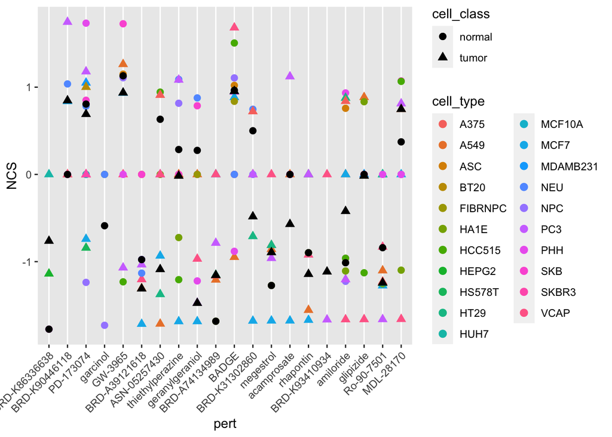

```r
drugs_lincs_top <- unique(lincs_res$pert)[1:20]
gess_res_vis(lincs_res, drugs = drugs_lincs_top, col = "NCS")
```

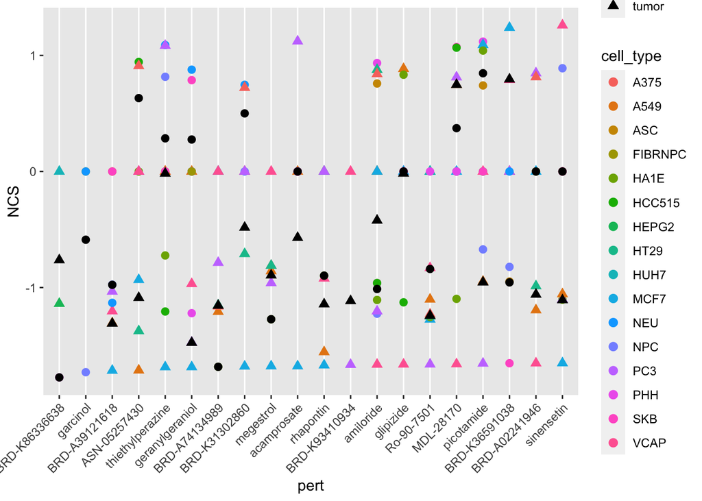

```r
lincs_res_down <- lincs_res[lincs_res$trend == "down",]
down_drug_lincs <- unique(lincs_res_down$pert)[1:20]
lincs_res_up  <- lincs_res[lincs_res$trend == "up",]
up_drug_lincs <- unique(lincs_res_up$pert)[1:20]

drugs_lincs_topdown <- unique(lincs_res_down$pert)[1:20]
gess_res_vis(lincs_res, drugs = drugs_lincs_topdown , col = "NCS")
```

```r
tsea_lincs_down <- tsea_dup_hyperG(drugs = drugs_lincs_topdown[1:20], type = "KEGG",
                               pvalueCutoff=0.5, qvalueCutoff = 0.5)
```

```
## No targets found in DrugBank/CLUE/STITCH database for 12 drugs:
## brd-k86336638 / garcinol / brd-a39121618 / asn-05257430 / geranylgeraniol / brd-a74134989 / brd-k31302860 / rhapontin / brd-k93410934 / brd-k36591038 / brd-a02241946 / sinensetin
```

```r
result(tsea_lincs_down)
```

```
## # A tibble: 50 x 9
##    ID     Description GeneRatio BgRatio   pvalue p.adjust   qvalue itemID  Count
##    <chr>  <chr>       <chr>     <chr>      <dbl>    <dbl>    <dbl> <chr>   <int>
##  1 hsa05… Nicotine a… 22/53     40/8105 5.77e-40 5.31e-38 4.13e-38 2555/2…    22
##  2 hsa04… Neuroactiv… 26/53     341/81… 2.27e-22 1.04e-20 8.12e-21 1812/1…    26
##  3 hsa05… Morphine a… 16/53     91/8105 1.71e-19 5.25e-18 4.08e-18 1812/2…    16
##  4 hsa04… GABAergic … 15/53     89/8105 5.32e-18 1.22e-16 9.52e-17 2555/2…    15
##  5 hsa04… Retrograde… 16/53     148/81… 5.60e-16 1.03e-14 8.01e-15 2555/2…    16
##  6 hsa04… Taste tran… 10/53     86/8105 1.42e-10 2.18e- 9 1.70e- 9 2555/2…    10
##  7 hsa05… Cocaine ad… 8/53      49/8105 7.09e-10 9.31e- 9 7.25e- 9 1812/2…     8
##  8 hsa05… Amphetamin… 8/53      69/8105 1.19e- 8 1.37e- 7 1.06e- 7 1812/2…     8
##  9 hsa04… Glutamater… 8/53      114/81… 6.26e- 7 6.40e- 6 4.98e- 6 2902/2…     8
## 10 hsa04… cAMP signa… 10/53     216/81… 1.05e- 6 9.66e- 6 7.52e- 6 1812/2…    10
## # … with 40 more rows
```

```r
write.csv2(result(tsea_lincs_down), file =  "/Users/eramsey/Desktop/R21_210302/PreliminaryR21/signatureSearch_outputs/210526_lincs_tsea.csv")
```

```r
dsea_res_lincs <- dsea_hyperG(drugs = drugs_lincs_topdown, type = "KEGG",
                            pvalueCutoff = 0.05 , qvalueCutoff = 0.05,
                            minGSSize = 2, maxGSSize = 2000)
result(dsea_res_lincs)
```

```
## # A tibble: 0 x 9
## # … with 9 variables: ID <chr>, Description <chr>, GeneRatio <chr>,
## #   BgRatio <chr>, pvalue <dbl>, p.adjust <dbl>, qvalue <dbl>, itemID <chr>,
## #   Count <int>
```

```r
#0 rows
```

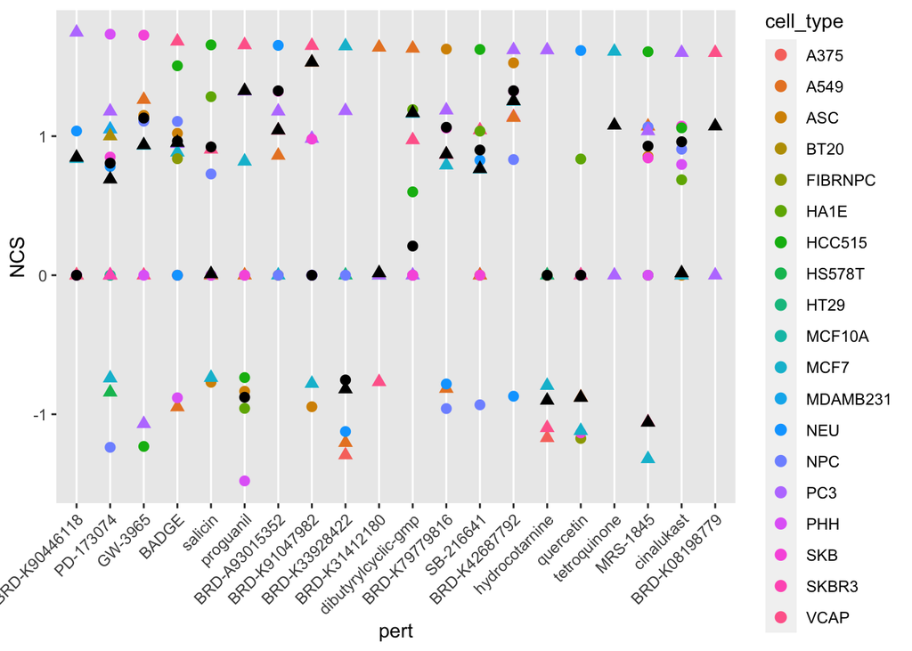

```r
drugs_lincs_topup <- unique(lincs_res_up$pert)[1:20]
gess_res_vis(lincs_res, drugs = drugs_lincs_topup , col = "NCS")
```

```r
tsea_lincs_up <- tsea_dup_hyperG(drugs = drugs_lincs_topup[1:20], type = "KEGG",
                               pvalueCutoff=0.5, qvalueCutoff = 0.5)
```

```
## No targets found in DrugBank/CLUE/STITCH database for 13 drugs:
## brd-k90446118 / badge / salicin / brd-a93015352 / brd-k91047982 / brd-k33928422 / brd-k31412180 / dibutyrylcyclic-gmp / brd-k79779816 / brd-k42687792 / hydrocotarnine / tetroquinone / brd-k08198779
```

```r
result(tsea_lincs_up)
```

```
## # A tibble: 113 x 9
##    ID     Description  GeneRatio BgRatio  pvalue p.adjust  qvalue itemID   Count
##    <chr>  <chr>        <chr>     <chr>     <dbl>    <dbl>   <dbl> <chr>    <int>
##  1 hsa04… Calcium sig… 12/47     240/81… 7.20e-9  1.20e-6 9.18e-7 2263/22…    12
##  2 hsa04… Rap1 signal… 10/47     210/81… 2.47e-7  2.06e-5 1.57e-5 2263/22…    10
##  3 hsa04… PI3K-Akt si… 11/47     354/81… 3.99e-6  1.62e-4 1.24e-4 2263/22…    11
##  4 hsa04… MAPK signal… 10/47     294/81… 5.32e-6  1.62e-4 1.24e-4 2263/22…    10
##  5 hsa01… EGFR tyrosi… 6/47      79/8105 5.53e-6  1.62e-4 1.24e-4 2263/22…     6
##  6 hsa04… Ras signali… 9/47      232/81… 5.83e-6  1.62e-4 1.24e-4 2263/22…     9
##  7 hsa05… Central car… 5/47      70/8105 4.81e-5  1.08e-3 8.21e-4 2263/22…     5
##  8 hsa04… Adherens ju… 5/47      71/8105 5.16e-5  1.08e-3 8.21e-4 60/1457…     5
##  9 hsa04… Focal adhes… 7/47      201/81… 1.41e-4  2.61e-3 1.99e-3 2321/23…     7
## 10 hsa05… Prostate ca… 5/47      97/8105 2.28e-4  3.53e-3 2.70e-3 2263/51…     5
## # … with 103 more rows
```

```r
write.csv2(result(tsea_lincs_up), file = "/Users/eramsey/Desktop/R21_210302/PreliminaryR21/signatureSearch_outputs/210526_lincs_up_tsea.csv" )
```

```r
dsea_lincs_down <- dsea_hyperG(drugs = drugs_lincs_topdown, type = "KEGG",
                            pvalueCutoff = 0.05 , qvalueCutoff = 0.05,
                            minGSSize = 2, maxGSSize = 2000)
result(dsea_lincs_down)
```

```
## # A tibble: 0 x 9
## # … with 9 variables: ID <chr>, Description <chr>, GeneRatio <chr>,
## #   BgRatio <chr>, pvalue <dbl>, p.adjust <dbl>, qvalue <dbl>, itemID <chr>,
## #   Count <int>
```

```r
#drugs_top20 <- unique(lincs_res_up$pert)[1:20]
#gess_res_vis(lincs_res, drugs = drugs_top20 , col = "NCS")
```